# NYC Schools Perceptions

Sofiane Ikkour

### **Context:**

In this project we’re going to take a look at and analyze some surveys designed to gauge parent, student and teacher perceptions of the quality of New York City schools. Survey results provide insight into a school’s learning environment and contribute of diversification that goes beyond test scores.

### **Objective:**

Our goal in this project is to investigate on how student, parent and teacher perceptions appear to be related to demographic and academic success metrics and find out if students, parents and teachers have similar perceptions of NYC school quality.

### **Dataset:**

We’ll work on several datasets which are listed below:

- Survey data Dictionary.xls
- masterfile11_gened_final.xlsx
- masterfile11_gened_final.txt
- masterfile11_d75_final.xlsx
- masterfile11_d75_final.txt
- combined.csv

The first file, Survey data Dictionary.xls, contains metadata that will be useful for cleaning and preparing the survey data for analysis.  
The next two files, masterfile11_gened_final.xlsx and masterfile11_gened_final.txt, contain survey data for “general education” schools - those that do not serve populations with special needs.  
The files, masterfile11_d75_final.xlsx and masterfile11_d75_final.txt, contain survey data for District 75 Schools, which provide exceptional education support for children with special needs such as learning and physical disabilities.  
I downloaded the first five files from this [link](https://data.cityofnewyork.us/Education/2011-NYC-School-Survey/mnz3-dyi8).  
The last file combined.csv, contains a list of schools with information about location, test exam scores, class sizes…  
This last file was downloaded from [here](https://data.world/dataquest/nyc-schools-data/workspace/file?filename=combined.csv).

**Note:** This code was written on RStudio.  
**Packages:** readr, dplyr, tidyr, stringr, purrr, ggplot2.  
**Programming language:** R.

**Read and explore the datasets:**

```r
# set working directory
setwd("C:/Users/Aylan/Documents/IT/DataQuest/R/NYC Schools Perceptions/2011 data files online")

# load the relevant libraries
library(readr)
library(dplyr)
# load the combined.csv dataset
combined <- read_csv("combined.csv", col_types = cols())

# display the first few rows
head(combined)
```

```
## # A tibble: 6 x 30
##   DBN    school_name      `Num of SAT Test ~ `SAT Critical Rea~ `SAT Math Avg. ~
##   <chr>  <chr>                         <dbl>              <dbl>            <dbl>
## 1 01M292 HENRY STREET SC~                 29                355              404
## 2 01M448 UNIVERSITY NEIG~                 91                383              423
## 3 01M450 EAST SIDE COMMU~                 70                377              402
## 4 01M458 FORSYTH SATELLI~                  7                414              401
## 5 01M509 MARTA VALLE HIG~                 44                390              433
## 6 01M515 LOWER EAST SIDE~                112                332              557
## # ... with 25 more variables: SAT Writing Avg. Score <dbl>,
## #   avg_sat_score <dbl>, AP Test Takers <dbl>, Total Exams Taken <dbl>,
## #   Number of Exams with scores 3 4 or 5 <dbl>, exams_per_student <dbl>,
## #   high_score_percent <dbl>, avg_class_size <dbl>, frl_percent <dbl>,
## #   total_enrollment <dbl>, ell_percent <dbl>, sped_percent <dbl>,
## #   selfcontained_num <dbl>, asian_per <dbl>, black_per <dbl>,
## #   hispanic_per <dbl>, white_per <dbl>, male_per <dbl>, female_per <dbl>, ...
```

```r
# display the number of rows and columns of the combined dataframe
print(paste("number of rows of combined:", dim(combined)[1]))
```

```
## [1] "number of rows of combined: 479"
```

```r
print(paste("number of columns of combined:", dim(combined)[2]))
```

```
## [1] "number of columns of combined: 30"
```

```r
# set working directory
setwd("C:/Users/Aylan/Documents/IT/DataQuest/R/NYC Schools Perceptions/2011 data files online")

# read the masterfile11_gened_final.txt and masterfile11_D75_final.txt files and save them as dataframes
masterfile11_gened <- read_tsv("masterfile11_gened_final.txt", col_types = cols())
masterfile11_d75 <- read_tsv("masterfile11_d75_final.txt", col_types = cols())

# display the first fex rows of the masterfille11_gened dataframe
head(masterfile11_gened)
```

```
## # A tibble: 6 x 1,942
##   dbn    bn    schoolname      d75 studentssurveyed highschool schooltype   rr_s
##   <chr>  <chr> <chr>         <dbl> <chr>                 <dbl> <chr>       <dbl>
## 1 01M015 M015  P.S. 015 Rob~     0 No                        0 Elementary~    NA
## 2 01M019 M019  P.S. 019 Ash~     0 No                        0 Elementary~    NA
## 3 01M020 M020  P.S. 020 Ann~     0 No                        0 Elementary~    NA
## 4 01M034 M034  P.S. 034 Fra~     0 Yes                       0 Elementary~    89
## 5 01M063 M063  P.S. 063 Wil~     0 No                        0 Elementary~    NA
## 6 01M064 M064  P.S. 064 Rob~     0 No                        0 Elementary~    NA
## # ... with 1,934 more variables: rr_t <dbl>, rr_p <dbl>, N_s <dbl>, N_t <dbl>,
## #   N_p <dbl>, nr_s <dbl>, nr_t <dbl>, nr_p <dbl>, saf_p_11 <dbl>,
## #   com_p_11 <dbl>, eng_p_11 <dbl>, aca_p_11 <dbl>, saf_t_11 <dbl>,
## #   com_t_11 <dbl>, eng_t_11 <dbl>, aca_t_11 <dbl>, saf_s_11 <dbl>,
## #   com_s_11 <dbl>, eng_s_11 <dbl>, aca_s_11 <dbl>, saf_tot_11 <dbl>,
## #   com_tot_11 <dbl>, eng_tot_11 <dbl>, aca_tot_11 <dbl>, p_q2h <dbl>,
## #   p_q7a <dbl>, p_q7b <dbl>, p_q7c <dbl>, p_q7d <dbl>, p_q8a <dbl>, ...
```

```r
# display the number of rows and columns of the masterfile11_gened dataframe
print(paste("number of rows of masterfil11_gened:", dim(masterfile11_gened)[1]))
```

```
## [1] "number of rows of masterfil11_gened: 1646"
```

```r
print(paste("number of columns of masterfile_gened:", dim(masterfile11_gened)[2]))
```

```
## [1] "number of columns of masterfile_gened: 1942"
```

```r
# display the first few rows of the masterfille11_d75 dataframe
head(masterfile11_d75)
```

```
## # A tibble: 6 x 1,773
##   dbn    bn    schoolname   d75 studentssurveyed highschool schooltype      rr_s
##   <chr>  <chr> <chr>      <dbl> <chr>                 <dbl> <chr>          <dbl>
## 1 75K004 K004  P.S. K004      1 Yes                       0 District 75 S~    38
## 2 75K036 K036  P.S. 36        1 Yes                      NA District 75 S~    70
## 3 75K053 K053  P.S. K053      1 Yes                      NA District 75 S~    94
## 4 75K077 K077  P.S. K077      1 Yes                      NA District 75 S~    95
## 5 75K140 K140  P.S. K140      1 Yes                       0 District 75 S~    77
## 6 75K141 K141  P.S. K141      1 Yes                      NA District 75 S~    73
## # ... with 1,765 more variables: rr_t <dbl>, rr_p <dbl>, N_s <dbl>, N_t <dbl>,
## #   N_p <dbl>, nr_s <dbl>, nr_t <dbl>, nr_p <dbl>, saf_p_11 <dbl>,
## #   com_p_11 <dbl>, eng_p_11 <dbl>, aca_p_11 <dbl>, saf_t_11 <dbl>,
## #   com_t_11 <dbl>, eng_t_11 <dbl>, aca_t_11 <dbl>, saf_s_11 <dbl>,
## #   com_s_11 <dbl>, eng_s_11 <dbl>, aca_s_11 <dbl>, saf_tot_11 <dbl>,
## #   com_tot_11 <dbl>, eng_tot_11 <dbl>, aca_tot_11 <dbl>, p_q1c <dbl>,
## #   p_q10a <dbl>, p_q10b <dbl>, p_q10c <dbl>, p_q10d <dbl>, p_q10e <dbl>, ...
```

```r
# display the number of rows and columns of the masterfile11_gened dataframe
print(paste("number of rows of masterfil11_d75:", dim(masterfile11_d75)[1]))
```

```
## [1] "number of rows of masterfil11_d75: 56"
```

```r
print(paste("number of columns of masterfile_d75:", dim(masterfile11_d75)[2]))
```

```
## [1] "number of columns of masterfile_d75: 1773"
```

**Discussion:**  
It’s quickly apparent that the dataframes above containing survey data are very large with hundreds of rows and columns. The survey data dictionary (please refer to the file) indicates that most of the variables in these dataframes provide granular information about survey responses. For example, the question s_q1a_1 contains for each school the number of students that responded to “option 1” of “question 1a”. Another remark we can make is about the variables in the data dictionary which end with _10. On the other hand, the variables in the dataframes we imported end with _11. This is because the data dictionary refers to the variables taken from the previous year, 2010. So this is one of the challenges we have to deal with while working with this dataset. After quickly examining the variables descriptions we can see that the following topics are involved in the study: Safety and respect, communication, engagement and academic expectations.

We are interested in studying the relationships between school quality perceptions and SAT scores. So we need to focus on the aggregate scores for each school calculated from the survey responses. Therefore, we can simplify our dataframes by creating new dataframes that contain only variables aggregating scores. In addition, we will retain the variable dbn since it will help us combine the survey dataframes with the combined dataframe. Finally, we will filter the dataframes by the schooltype variable in order to retain only the observations we need that relate to “High School”

```r
# simplify the masterfile11_gened dataframe by including the useful variables only
masterfile11_gened_filtered <- masterfile11_gened %>%
  select(dbn:schooltype, saf_p_11:aca_tot_11) %>%
  filter(schooltype == "High School")

# display the few first rows
print(head(masterfile11_gened_filtered))
```

```
## # A tibble: 6 x 23
##   dbn    bn    schoolname    d75 studentssurveyed highschool schooltype saf_p_11
##   <chr>  <chr> <chr>       <dbl> <chr>                 <dbl> <chr>         <dbl>
## 1 01M448 M448  University~     0 Yes                      NA High Scho~      7.9
## 2 01M458 M458  Forsyth Sa~     0 Yes                      NA High Scho~      8.1
## 3 01M509 M509  Marta Vall~     0 Yes                      NA High Scho~      7.7
## 4 01M515 M515  Lower East~     0 Yes                      NA High Scho~      8.3
## 5 01M650 M650  Cascades H~     0 Yes                      NA High Scho~      9
## 6 01M696 M696  Bard High ~     0 Yes                      NA High Scho~      8.8
## # ... with 15 more variables: com_p_11 <dbl>, eng_p_11 <dbl>, aca_p_11 <dbl>,
## #   saf_t_11 <dbl>, com_t_11 <dbl>, eng_t_11 <dbl>, aca_t_11 <dbl>,
## #   saf_s_11 <dbl>, com_s_11 <dbl>, eng_s_11 <dbl>, aca_s_11 <dbl>,
## #   saf_tot_11 <dbl>, com_tot_11 <dbl>, eng_tot_11 <dbl>, aca_tot_11 <dbl>
```

```r
# display the number of rows and columns of the masterfile11_gened_filtered dataframe
print(paste("number of rows of masterfil11_gened_filtered:", dim(masterfile11_gened_filtered)[1]))
```

```
## [1] "number of rows of masterfil11_gened_filtered: 383"
```

```r
print(paste("number of columns of masterfile_gened_filtered:", dim(masterfile11_gened_filtered)[2]))
```

```
## [1] "number of columns of masterfile_gened_filtered: 23"
```

```r
# simplify the masterfile11_d75 dataframe by including the useful variables only
masterfile11_d75_filtered <- masterfile11_d75 %>%
  select(dbn:schooltype, saf_p_11:aca_tot_11)

# display the few first rows
head(masterfile11_d75_filtered)
```

```
## # A tibble: 6 x 23
##   dbn    bn    schoolname   d75 studentssurveyed highschool schooltype  saf_p_11
##   <chr>  <chr> <chr>      <dbl> <chr>                 <dbl> <chr>          <dbl>
## 1 75K004 K004  P.S. K004      1 Yes                       0 District 7~      9.1
## 2 75K036 K036  P.S. 36        1 Yes                      NA District 7~      9.2
## 3 75K053 K053  P.S. K053      1 Yes                      NA District 7~      8.8
## 4 75K077 K077  P.S. K077      1 Yes                      NA District 7~      9.4
## 5 75K140 K140  P.S. K140      1 Yes                       0 District 7~      8.6
## 6 75K141 K141  P.S. K141      1 Yes                      NA District 7~      8.8
## # ... with 15 more variables: com_p_11 <dbl>, eng_p_11 <dbl>, aca_p_11 <dbl>,
## #   saf_t_11 <dbl>, com_t_11 <dbl>, eng_t_11 <dbl>, aca_t_11 <dbl>,
## #   saf_s_11 <dbl>, com_s_11 <dbl>, eng_s_11 <dbl>, aca_s_11 <dbl>,
## #   saf_tot_11 <dbl>, com_tot_11 <dbl>, eng_tot_11 <dbl>, aca_tot_11 <dbl>
```

```r
# display the number of rows and columns of the masterfile11_gened_filtered dataframe
print(paste("number of rows of masterfil11_d75_filtered:", dim(masterfile11_d75_filtered)[1]))
```

```
## [1] "number of rows of masterfil11_d75_filtered: 56"
```

```r
print(paste("number of columns of masterfile11_d75_filtered:", dim(masterfile11_d75_filtered)[2]))
```

```
## [1] "number of columns of masterfile11_d75_filtered: 23"
```

**Discussion:**  
By going down from more than a thousand columns to just 23 we simplified the dataframes and working with them is now more manageable. Next, we’ll join these dataframes to the combined dataframe. Since we’re interested in relationships between survey data and the combined dataframe, we’ll retain observations from survey data that correspond to the combined dataframe. However, before we do that, we need to combine the survey dataframe into a single dataframe by row.

```r
# combine the masterfile11_gened_filtered and masterfile11_d75_filtered dataframes by row
masterfile11_gened_d75 <- bind_rows(masterfile11_gened_filtered, masterfile11_d75_filtered)

# display the first few rows
head(masterfile11_gened_d75)
```

```
## # A tibble: 6 x 23
##   dbn    bn    schoolname    d75 studentssurveyed highschool schooltype saf_p_11
##   <chr>  <chr> <chr>       <dbl> <chr>                 <dbl> <chr>         <dbl>
## 1 01M448 M448  University~     0 Yes                      NA High Scho~      7.9
## 2 01M458 M458  Forsyth Sa~     0 Yes                      NA High Scho~      8.1
## 3 01M509 M509  Marta Vall~     0 Yes                      NA High Scho~      7.7
## 4 01M515 M515  Lower East~     0 Yes                      NA High Scho~      8.3
## 5 01M650 M650  Cascades H~     0 Yes                      NA High Scho~      9
## 6 01M696 M696  Bard High ~     0 Yes                      NA High Scho~      8.8
## # ... with 15 more variables: com_p_11 <dbl>, eng_p_11 <dbl>, aca_p_11 <dbl>,
## #   saf_t_11 <dbl>, com_t_11 <dbl>, eng_t_11 <dbl>, aca_t_11 <dbl>,
## #   saf_s_11 <dbl>, com_s_11 <dbl>, eng_s_11 <dbl>, aca_s_11 <dbl>,
## #   saf_tot_11 <dbl>, com_tot_11 <dbl>, eng_tot_11 <dbl>, aca_tot_11 <dbl>
```

```r
# join the new dataframe to the combined dataframe using the left_join() function and the common variable dbn
# we can notice that the name of column dbn is lowercase in the masterfile11_gened_d75 dataframe and uppercase in the combined dataframe
# we need to rename one of the columns before joining the two dataframes
# let's rename the dbn column with lowercase letters and convert it to uppercase
masterfile11_gened_d75 <- rename(masterfile11_gened_d75, DBN = dbn)

# display the few first rows
head(masterfile11_gened_d75)
```

```
## # A tibble: 6 x 23
##   DBN    bn    schoolname    d75 studentssurveyed highschool schooltype saf_p_11
##   <chr>  <chr> <chr>       <dbl> <chr>                 <dbl> <chr>         <dbl>
## 1 01M448 M448  University~     0 Yes                      NA High Scho~      7.9
## 2 01M458 M458  Forsyth Sa~     0 Yes                      NA High Scho~      8.1
## 3 01M509 M509  Marta Vall~     0 Yes                      NA High Scho~      7.7
## 4 01M515 M515  Lower East~     0 Yes                      NA High Scho~      8.3
## 5 01M650 M650  Cascades H~     0 Yes                      NA High Scho~      9
## 6 01M696 M696  Bard High ~     0 Yes                      NA High Scho~      8.8
## # ... with 15 more variables: com_p_11 <dbl>, eng_p_11 <dbl>, aca_p_11 <dbl>,
## #   saf_t_11 <dbl>, com_t_11 <dbl>, eng_t_11 <dbl>, aca_t_11 <dbl>,
## #   saf_s_11 <dbl>, com_s_11 <dbl>, eng_s_11 <dbl>, aca_s_11 <dbl>,
## #   saf_tot_11 <dbl>, com_tot_11 <dbl>, eng_tot_11 <dbl>, aca_tot_11 <dbl>
```

```r
# now that the name of the column is changed we can join the dataframe with the combined dataframe
masterfile11_combined <- combined %>%
  left_join(masterfile11_gened_d75, by = "DBN")

# display the first few rows
head(masterfile11_combined)
```

```
## # A tibble: 6 x 52
##   DBN    school_name      `Num of SAT Test ~ `SAT Critical Rea~ `SAT Math Avg. ~
##   <chr>  <chr>                         <dbl>              <dbl>            <dbl>
## 1 01M292 HENRY STREET SC~                 29                355              404
## 2 01M448 UNIVERSITY NEIG~                 91                383              423
## 3 01M450 EAST SIDE COMMU~                 70                377              402
## 4 01M458 FORSYTH SATELLI~                  7                414              401
## 5 01M509 MARTA VALLE HIG~                 44                390              433
## 6 01M515 LOWER EAST SIDE~                112                332              557
## # ... with 47 more variables: SAT Writing Avg. Score <dbl>,
## #   avg_sat_score <dbl>, AP Test Takers <dbl>, Total Exams Taken <dbl>,
## #   Number of Exams with scores 3 4 or 5 <dbl>, exams_per_student <dbl>,
## #   high_score_percent <dbl>, avg_class_size <dbl>, frl_percent <dbl>,
## #   total_enrollment <dbl>, ell_percent <dbl>, sped_percent <dbl>,
## #   selfcontained_num <dbl>, asian_per <dbl>, black_per <dbl>,
## #   hispanic_per <dbl>, white_per <dbl>, male_per <dbl>, female_per <dbl>, ...
```

**Data analysis:**

Now that we have a single and clean dataframe to work with, we can begin our analysis by figuring out whether or not student, teacher and parent perceptions of NYC school quality is related to demographic and academic success metrics.

```r
# create a correlation matrix to show correlations between test scores and perceptions of school quality
library(purrr) # load the relevant library
cor_mat <- masterfile11_combined %>%
  select(avg_sat_score, saf_p_11:aca_tot_11) %>%
  cor(use = "pairwise.complete.obs")

# convert the correlation matrix to a tibble
cor_tib <- cor_mat %>%
  as_tibble(rownames = "variable")

# display the tibble
head(cor_tib, 20)
```

```
## # A tibble: 17 x 18
##    variable  avg_sat_score saf_p_11 com_p_11 eng_p_11 aca_p_11 saf_t_11 com_t_11
##    <chr>             <dbl>    <dbl>    <dbl>    <dbl>    <dbl>    <dbl>    <dbl>
##  1 avg_sat_~       1         0.0891   -0.114  0.00943  0.00828    0.309    0.107
##  2 saf_p_11        0.0891    1         0.803  0.798    0.817      0.490    0.232
##  3 com_p_11       -0.114     0.803     1      0.929    0.926      0.315    0.241
##  4 eng_p_11        0.00943   0.798     0.929  1        0.908      0.339    0.268
##  5 aca_p_11        0.00828   0.817     0.926  0.908    1          0.415    0.286
##  6 saf_t_11        0.309     0.490     0.315  0.339    0.415      1        0.744
##  7 com_t_11        0.107     0.232     0.241  0.268    0.286      0.744    1
##  8 eng_t_11        0.0561    0.314     0.307  0.330    0.373      0.799    0.903
##  9 aca_t_11        0.141     0.364     0.347  0.359    0.419      0.845    0.896
## 10 saf_s_11        0.277     0.732     0.541  0.539    0.593      0.592    0.253
## 11 com_s_11        0.162     0.617     0.569  0.545    0.598      0.383    0.168
## 12 eng_s_11        0.170     0.647     0.591  0.608    0.623      0.457    0.259
## 13 aca_s_11        0.293     0.692     0.615  0.624    0.680      0.493    0.265
## 14 saf_tot_~       0.276     0.828     0.611  0.621    0.683      0.844    0.507
## 15 com_tot_~       0.0891    0.642     0.693  0.682    0.712      0.736    0.800
## 16 eng_tot_~       0.0948    0.664     0.671  0.710    0.720      0.757    0.721
## 17 aca_tot_~       0.174     0.700     0.703  0.705    0.789      0.782    0.694
## # ... with 10 more variables: eng_t_11 <dbl>, aca_t_11 <dbl>, saf_s_11 <dbl>,
## #   com_s_11 <dbl>, eng_s_11 <dbl>, aca_s_11 <dbl>, saf_tot_11 <dbl>,
## #   com_tot_11 <dbl>, eng_tot_11 <dbl>, aca_tot_11 <dbl>
```

The correlation matrix shows different levels of correlations between the variables from weak and moderate to strong correlations. Let’s filter and index our tibble to identify moderate to strong relationships between the variables and avg_sat_score.

```r
cor_tib_indexed <- cor_tib %>%
  select(variable, avg_sat_score) %>%
  filter(avg_sat_score > 0.25 | avg_sat_score < -0.25)

# display the tibble
head(cor_tib_indexed)
```

```
## # A tibble: 5 x 2
##   variable      avg_sat_score
##   <chr>                 <dbl>
## 1 avg_sat_score         1
## 2 saf_t_11              0.309
## 3 saf_s_11              0.277
## 4 aca_s_11              0.293
## 5 saf_tot_11            0.276
```

We can explore more in depth those relationships using scatter plots.

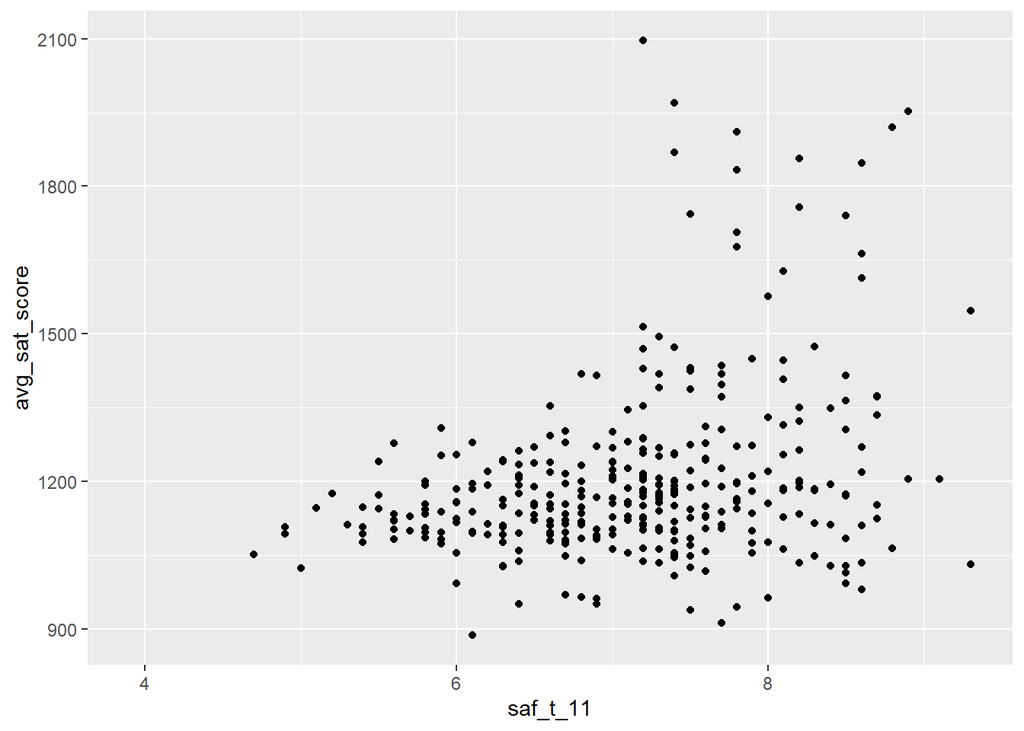

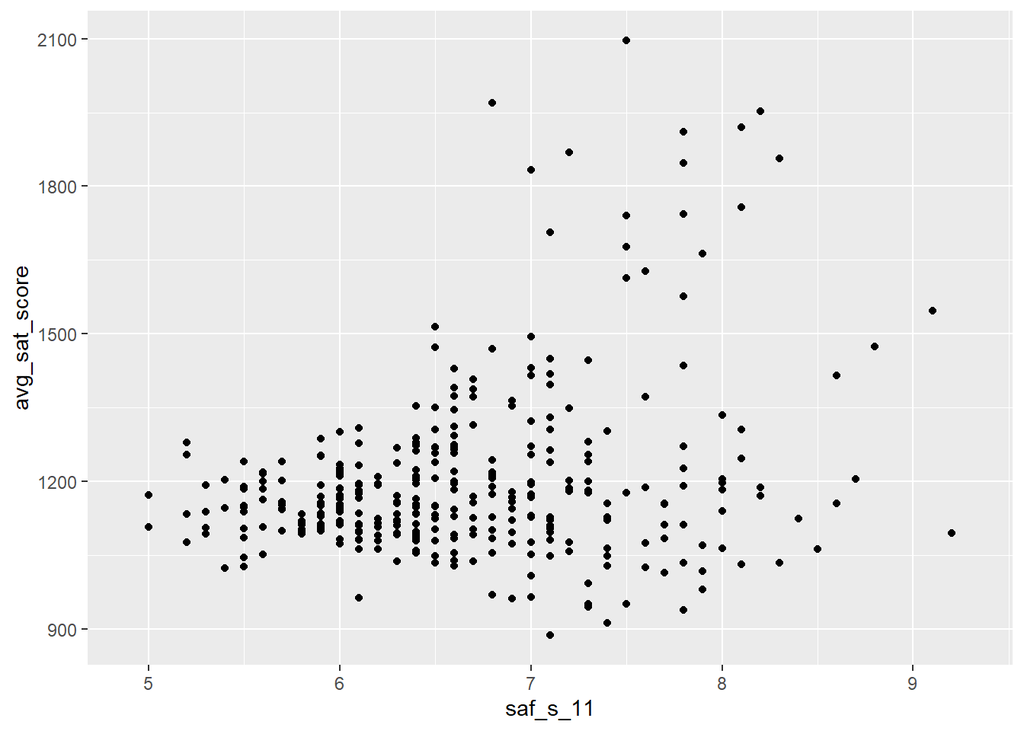

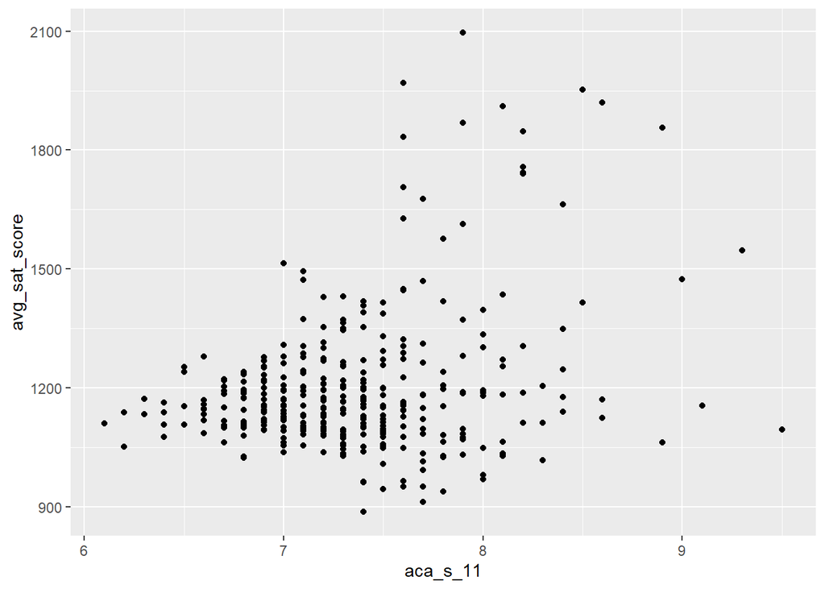

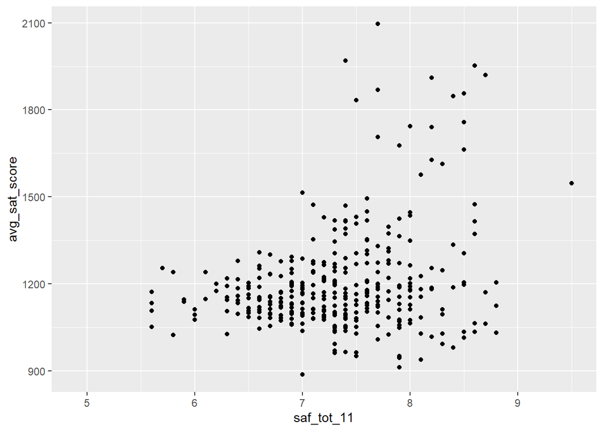

```r
library(ggplot2) # load the relevant library

# create a function that creates a scatter plot
scatter_plot <- function(x, y) {
  ggplot(data = masterfile11_combined,
         aes_string(x = x, y = y)) +
    geom_point()
}

# assign the variables saf_t_11, saf_s_11, aca_s_11 and aca_tot_11 to xvar and avg_sat_score to yvar
xvar <- cor_tib_indexed$variable[2:5]
yvar <- "avg_sat_score"

# use map2 function to plot our results
map2(xvar, yvar, scatter_plot)
```

These scatter plots reveal very weak to no correlations at all.  
Next, we’ll investigate on whether parents, students and teachers have similar perceptions about the four school quality metrics they were surveyed about: Safety and Respect, Communication, Engagement, Academic Expectations. We need to reshape the data for that.

```r
# reshape the dataframe so that the survey question and the score are in separate columns
library(tidyr) # load the relevant library
survey_data <- masterfile11_combined %>%
  select(DBN, schoolname, schooltype, saf_p_11:aca_tot_11) %>%
  pivot_longer(cols = c(saf_p_11:aca_tot_11),
               names_to = "Survey_Question",
               values_to = "Score")

# display the first few rows
head(survey_data)
```

```
## # A tibble: 6 x 5
##   DBN    schoolname schooltype Survey_Question Score
##   <chr>  <chr>      <chr>      <chr>           <dbl>
## 1 01M292 <NA>       <NA>       saf_p_11           NA
## 2 01M292 <NA>       <NA>       com_p_11           NA
## 3 01M292 <NA>       <NA>       eng_p_11           NA
## 4 01M292 <NA>       <NA>       aca_p_11           NA
## 5 01M292 <NA>       <NA>       saf_t_11           NA
## 6 01M292 <NA>       <NA>       com_t_11           NA
```

```r
# create two new variables response_type and metric
library(stringr) # load the relevant library
survey_data <- survey_data %>%
  mutate(response_type = str_sub(Survey_Question, 4, 6)) %>%
  mutate(metric = str_sub(Survey_Question, 1, 3)) %>%
  mutate(response_type = case_when(
    response_type == "_p_" ~ "parent",
    response_type == "_t_" ~ "teacher",
    response_type == "_s_" ~ "student",
    TRUE                   ~ "NA")) %>%
  mutate(metric = case_when(
    metric == "saf" ~ "Safety and Respect",
    metric == "com" ~ "Communication",
    metric == "eng" ~ "Engagement",
    TRUE            ~ "Academic Expectations"
  ))

# display the first few rows
head(survey_data)
```

```
## # A tibble: 6 x 7
##   DBN    schoolname schooltype Survey_Question Score response_type metric
##   <chr>  <chr>      <chr>      <chr>           <dbl> <chr>         <chr>
## 1 01M292 <NA>       <NA>       saf_p_11           NA parent        Safety and R~
## 2 01M292 <NA>       <NA>       com_p_11           NA parent        Communication
## 3 01M292 <NA>       <NA>       eng_p_11           NA parent        Engagement
## 4 01M292 <NA>       <NA>       aca_p_11           NA parent        Academic Exp~
## 5 01M292 <NA>       <NA>       saf_t_11           NA teacher       Safety and R~
## 6 01M292 <NA>       <NA>       com_t_11           NA teacher       Communication
```

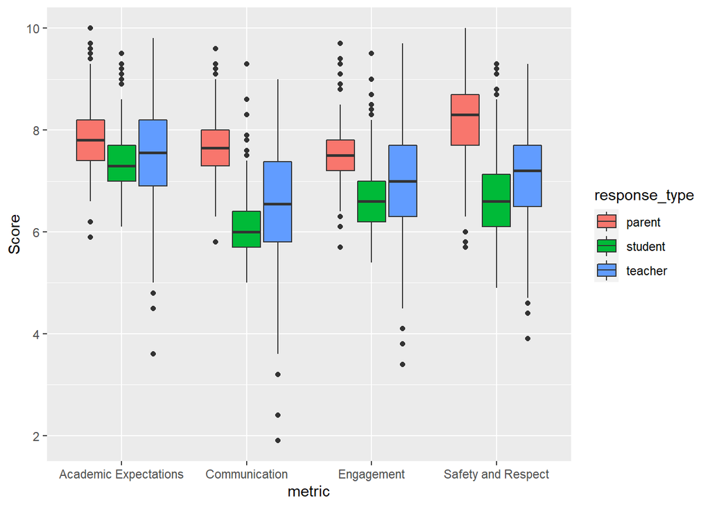

```r
# create a boxplot to see if the responders answered differently the four questions
survey_data %>%
  filter(response_type != "NA") %>%
  ggplot(aes(x = metric, y = Score, fill = response_type)) +
  geom_boxplot()
```

**Conclusion:**  
The boxplots show that the responders have different perceptions about the school quality metrics with parents answering with higher scores than students and teachers in each quality metric. On the other hand, students answered with lower scores than teachers and parents in each group.